# Brief

## Data Generation

### Fixed

- Students
  - 3000
- Schools
  - 100
- Pretest
  - ~ N(0,1)
- L1 Coefficients
  - Intercept = 0
  - Mobility = 1
  - Pretest = 1
- Error
  - ~ N(0,1)

### Manipulated

- p_{X,M}
  - 0
  - .25
  - .5
- Mobility %
  - .1
  - .25
- ICC
  - .15
  - .25
- L2 Coefficients
  - Mobility = .5, 1
  - Pretest = .5, 1

## Results

### Collapse across conditions

There is some variation due to conditions but on average the different estimation methods do not seem to have much difference

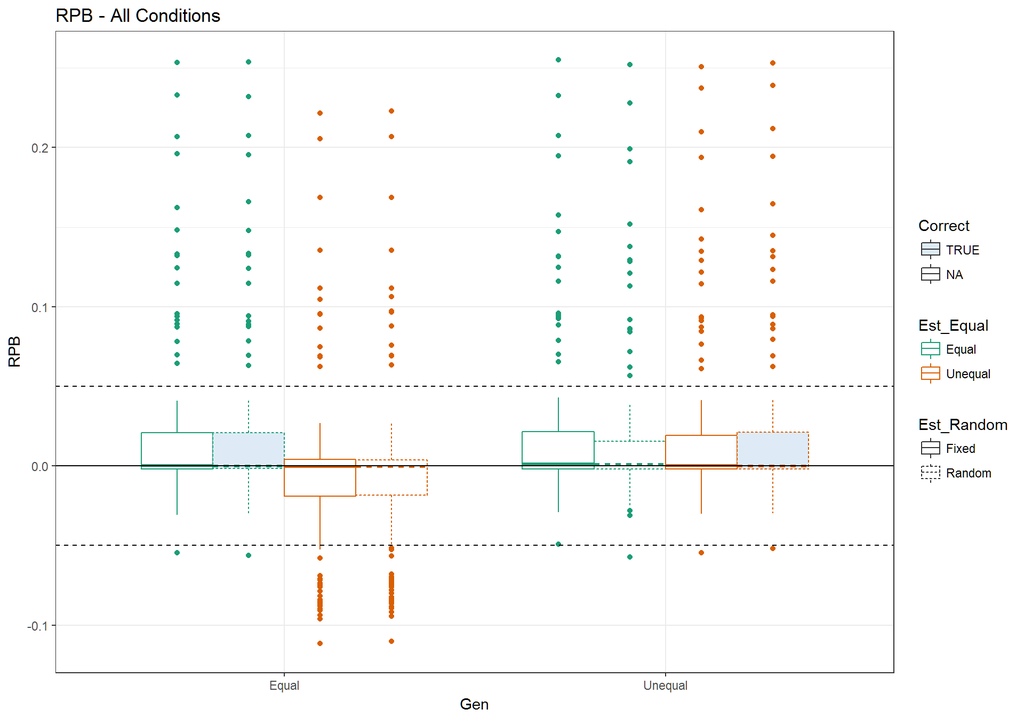

### RPB for each parameter across conditions

L1 fixed effects perform well with no apparent differences by weight and will be dropped for the remainder.

$\sigma$ is estimated well but left in. Notably this is the only parameter where correct weight specification consistantly outperforms

$\gamma_{M_j}$ displays substantial bias.

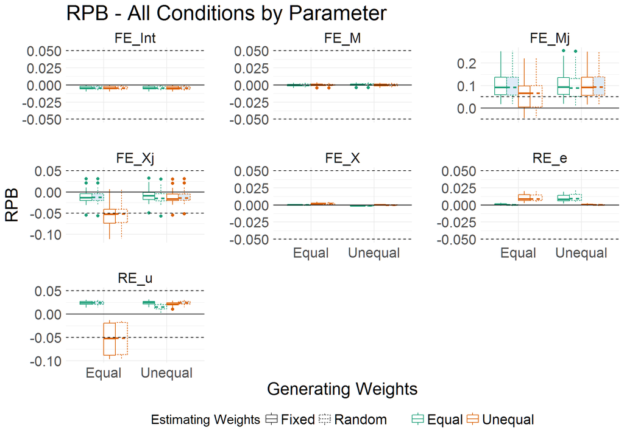

### RPB for each parameter by $\rho_{X,M}$

Bizarre relationship between $\rho$ and $\gamma_{M_j}$ bias

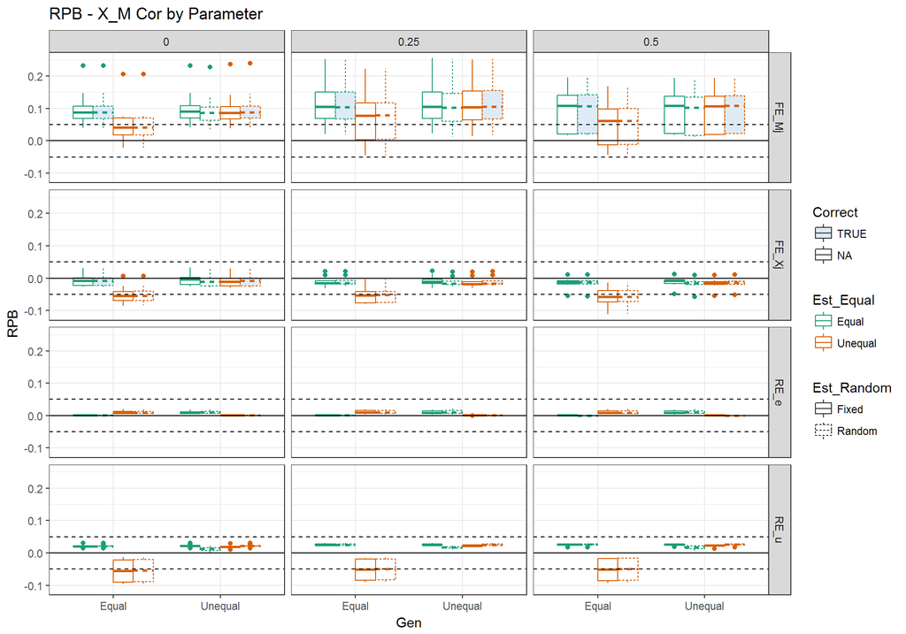

### RPB for each parameter by mobility %

$\gamma_{M_j}$seem biased with low mobility

For some reason Fixed and Random Unequal weights seem to diverge from other models here for $\tau_{00}$ and $\gamma_{X_j}$

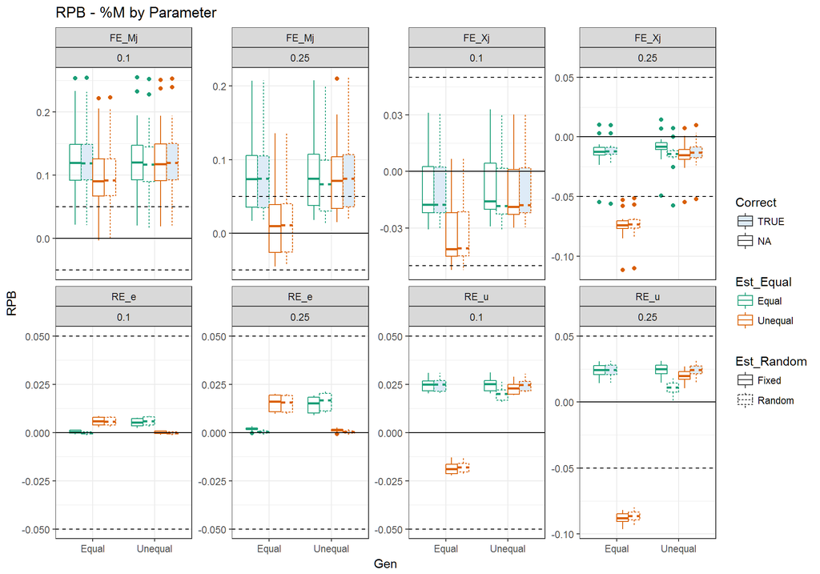

### RPB for each parameter by ICC

Larger ICC increases variability of $\gamma_{M_j}$ across other conditions, bias increased on average

Again Fixed and Random Unequal weights diverge under equal weight generation condition

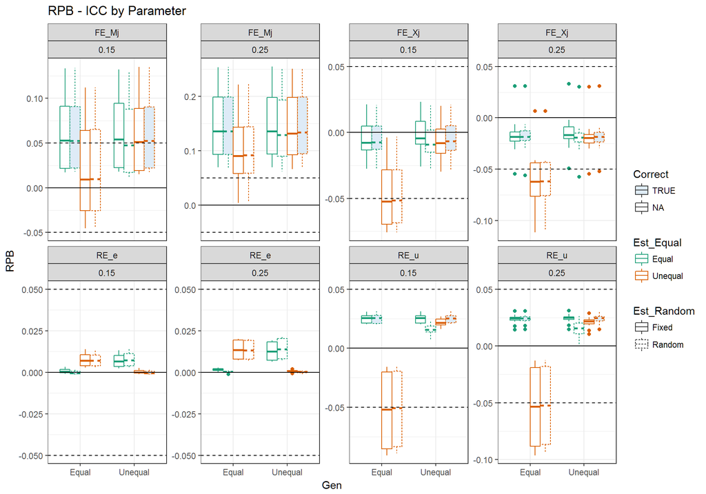

### RPB for each parameter by L2 effects

Note: “Strong” $\gamma_{M_j} = \gamma_{X_j} = 1$; “Weak” $\gamma_{M_j} = \gamma_{X_j} = .5$

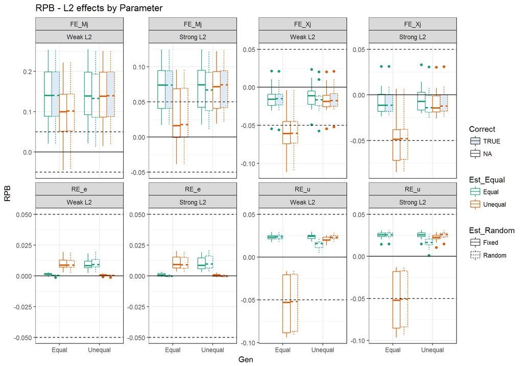

### $\gamma_{M_j}$

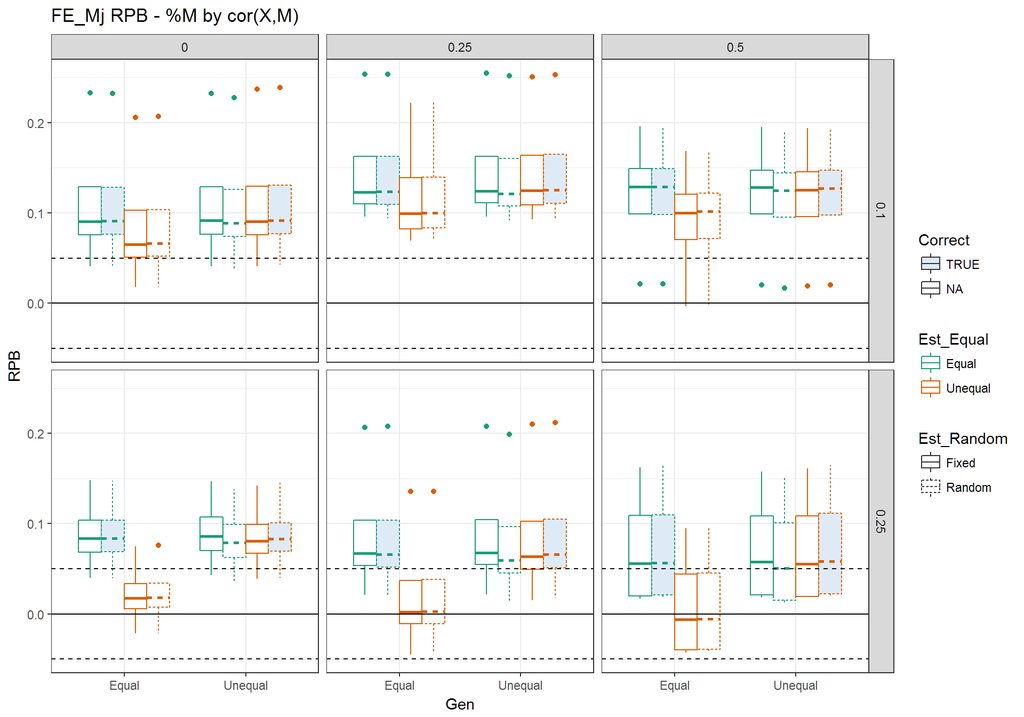

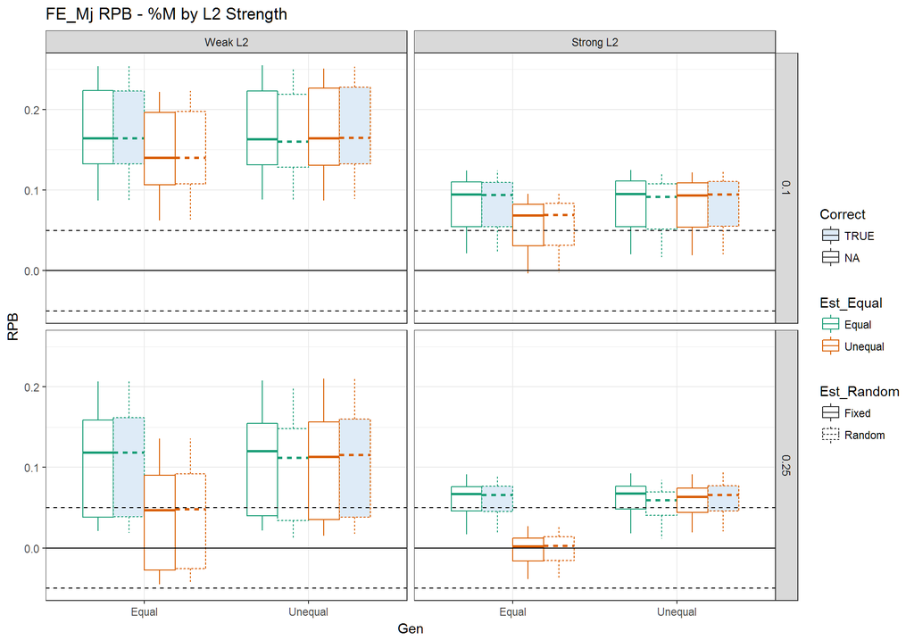

## Results - RMSE

Note: limited interpretability due to low number of iterations

### Collapse across conditions

There is some variation due to conditions but on average the different estimation methods do not seem to have much difference

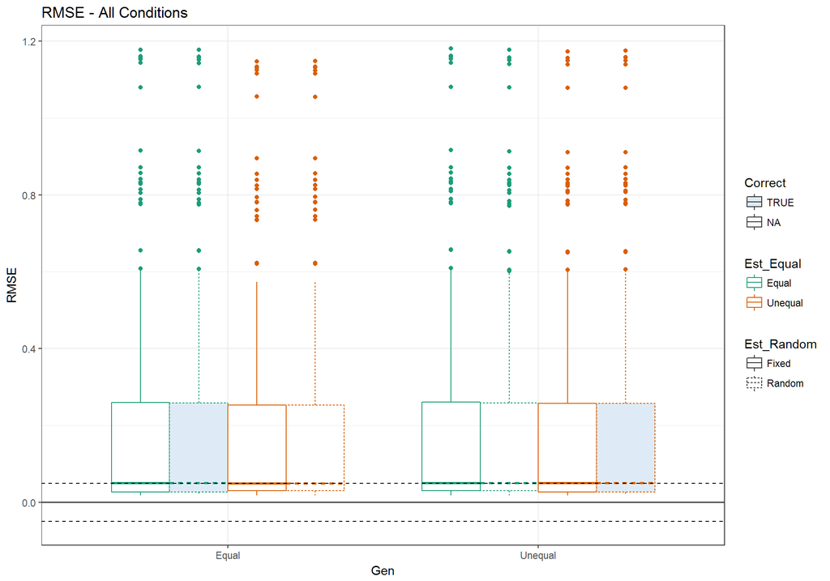

### RMSE for each parameter across conditions

L1 fixed effects perform well with no apparent differences by weight and will be dropped for the remainder.

$\sigma$ is estimated well but left in. Notably this is the only parameter where correct weight specification consistantly outperforms

$\gamma_{M_j}$ displays substantial bias.

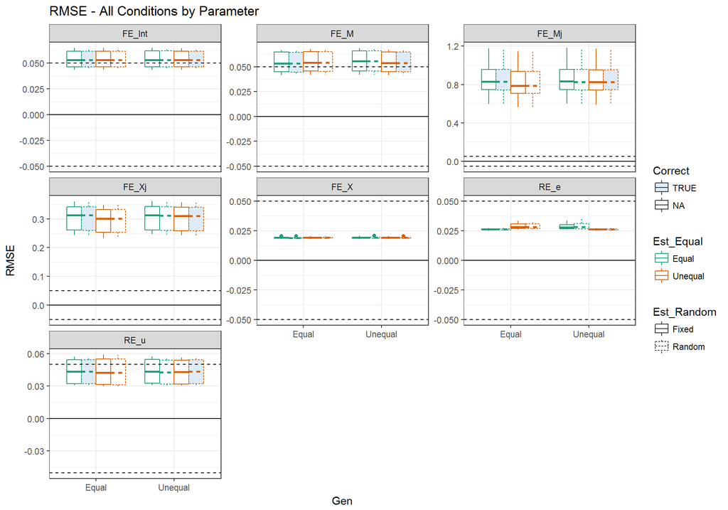

### RMSE for each parameter by $\rho_{X,M}$

Bizarre relationship between $\rho$ and $\gamma_{M_j}$ bias

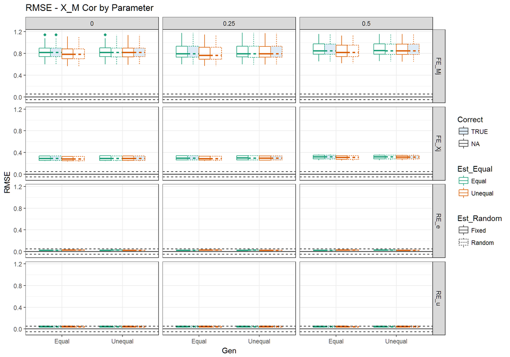

### RMSE for each parameter by mobility %

$\gamma_{M_j}$seem biased with low mobility

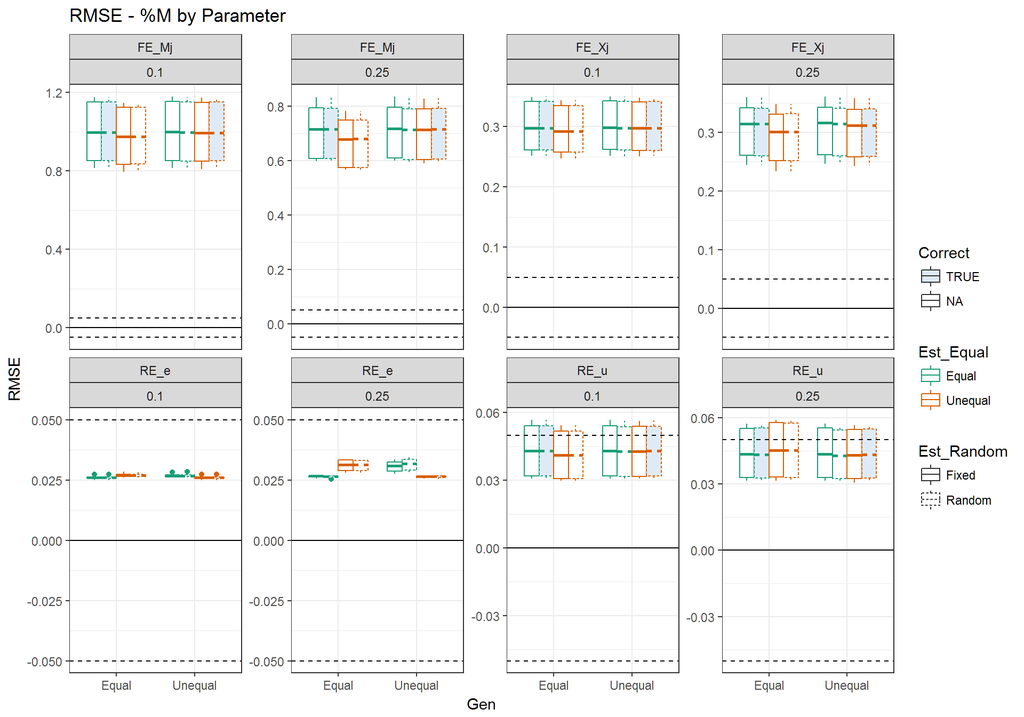

### RMSE for each parameter by ICC

Larger ICC increases variability of $\gamma_{M_j}$ across other conditions, bias increased on average

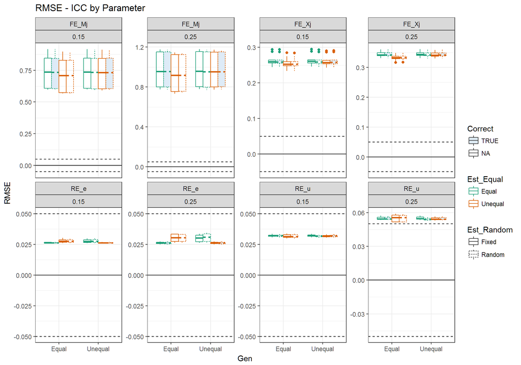

### RMSE for each parameter by L2 effects

Note: “Strong” $\gamma_{M_j} = \gamma_{X_j} = 1$; “Weak” $\gamma_{M_j} = \gamma_{X_j} = .5$

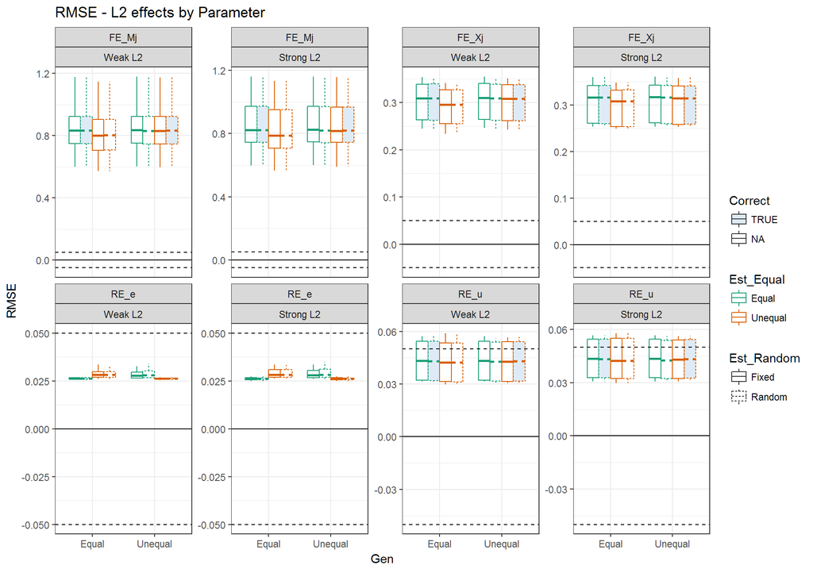

### $\gamma_{M_j}$

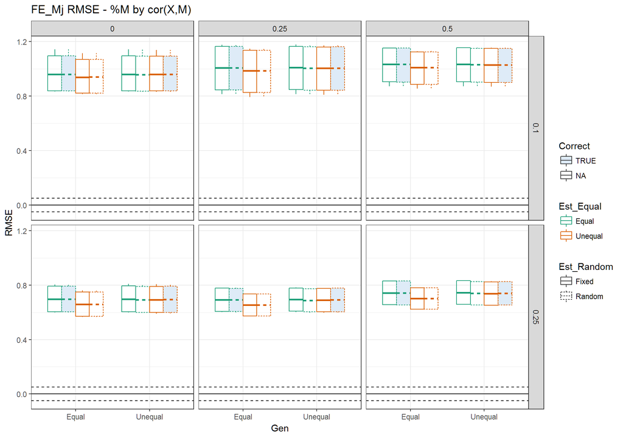

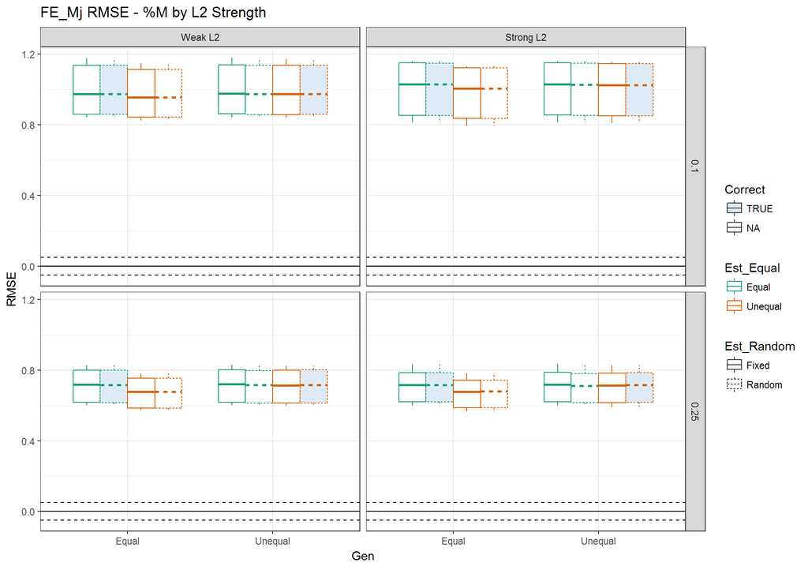